# Konstrukcja modelu prawdopodobieństwa wystąpienia szkody oraz średniej wartości szkody na potrzeby oszacowania ryzyka ubezpieczeniowego

Model średniej szkody

10 lipiec 2022

### Wczytanie danych

```r
data <- data.frame(read.csv("./dane/po_imputacji.csv", sep=';', encoding = "UTF-8", dec = ','))[,-1]
```

### Konwersja typów zmiennych

```r
data$PARENT1 <- as.logical(data$PARENT1)
data$MSTATUS <- as.logical(data$MSTATUS)
data$GENDER <- as.factor(data$GENDER)
data$EDUCATION <- as.factor(data$EDUCATION)
data$OCCUPATION <- as.factor(data$OCCUPATION)
data$CAR_USE <- as.factor(data$CAR_USE)
data$CAR_TYPE <- as.factor(data$CAR_TYPE)
data$RED_CAR <- as.logical(data$RED_CAR)
data$REVOKED <- as.logical(data$REVOKED)
data$CLAIM_FLAG <- as.logical(data$CLAIM_FLAG)
data$URBANICITY <- as.factor(data$URBANICITY)
data$OG_DATA <- as.logical(data$OG_DATA)
```

### Wybór grup referencyjnych dla zmiennych jakościowych

```r
data$OCCUPATION <- relevel(data$OCCUPATION, ref='Blue Collar')
data$CAR_USE <- relevel(data$CAR_USE, ref='Private')
data$EDUCATION <- relevel(data$EDUCATION, ref='<High School')
data$GENDER <- relevel(data$GENDER, ref='F')
data$CAR_TYPE <- relevel(data$CAR_TYPE, ref='SUV')
data$URBANICITY <- relevel(data$URBANICITY, ref='Highly Urban/ Urban')
```

Jako grupę referencyjną dla każdej ze zmiennych wybrano wariant najczęściej występujący w zbiorze danych. Wyjątkiem jest zmienna opisująca poziom edukacji, w przypadku której zdecydowano jako grupę referencyjną wybrać tę o najniższym wykształceniu.

### Podział zbioru na zestaw treningowy i testowy

Dane podzielono na zbiór uczący, na podstawie którego szacowane będą modele oraz zbiór testowy, który zostanie wykorzystano do ewaluacji modeli. Ponadto zmiennej X przypisano tę część zbioru uczącego, która zawiera zmienne objaśniające oraz znacznik imputacji (OG_data), natomiast zmiennej Y kolumnę CLM_AMT zawierającą wartość szkody.

```r
set.seed(1257)
n <- nrow(data)
random_nums <- sample(c(1:n), round(0.7*n), replace = FALSE)
data_train <- data[random_nums,]
data_test <- data[-random_nums,]


X <- subset(data_train[data_train$CLAIM_FLAG == TRUE,], select=-c(ID, CLM_AMT, CLAIM_FLAG))
Y <- data_train[data_train$CLAIM_FLAG == TRUE,]['CLM_AMT']
```

### Modele z jedną zmienną objaśniającą (rozkład gamma)

Do modelowania średniej szkody w ubezpieczeniach najczęściej wykorzystywany jest rozkład gamma lub rozkład odwrotny gaussowski. W celu uzyskania pożądanych właściwości interpretacyjnych modelu zastosowano logarytmiczną funkcję wiążącą.

Proces modelowania rozpoczęto od weryfikacji istnienia zależności pomiędzy modelowaną zmienną a każdym z potencjalnych predyktorów w modelach z jedną zmienną objaśniającą i rozkładem gamma.

```r
for (n in names(X)) {
  model_x <- glm(CLM_AMT ~ get(n), data=c(Y, X), family=Gamma(link="log"))
  cat(n, '\n')
  print(summary(model_x)$coefficients)
  cat('AIC: ', model_x$aic)
  cat('\n\n')
}
```

```
## KIDSDRIV
##               Estimate Std. Error    t value   Pr(>|t|)
## (Intercept) 8.61377757 0.03440168 250.388274 0.00000000
## get(n)      0.09307827 0.05028496   1.851016 0.06432308
## AIC:  36320.83
##
## AGE
##                Estimate  Std. Error    t value  Pr(>|t|)
## (Intercept) 8.585478335 0.150455049 57.0634114 0.0000000
## get(n)      0.001252278 0.003379396  0.3705628 0.7110047
## AIC:  36330.64
##
## HOMEKIDS
##               Estimate Std. Error    t value  Pr(>|t|)
## (Intercept) 8.60217078 0.04068870 211.414258 0.0000000
## get(n)      0.03900224 0.02670055   1.460728 0.1442562
## AIC:  36324.72
##
## YOJ
##                Estimate  Std. Error     t value  Pr(>|t|)
## (Intercept) 8.596670457 0.079820803 107.6996244 0.0000000
## get(n)      0.004294323 0.007259116   0.5915767 0.5542048
## AIC:  36330.07
##
## INCOME
##                 Estimate   Std. Error    t value   Pr(>|t|)
## (Intercept) 8.570831e+00 5.048333e-02 169.775476 0.00000000
## get(n)      1.328817e-06 7.634046e-07   1.740646 0.08190833
## AIC:  36322.7
##
## PARENT1
##               Estimate Std. Error    t value  Pr(>|t|)
## (Intercept) 8.61929392 0.03641807 236.676288 0.0000000
## get(n)TRUE  0.09292804 0.07854075   1.183182 0.2368856
## AIC:  36326.75
##
## HOME_VAL
##                 Estimate   Std. Error     t value  Pr(>|t|)
## (Intercept) 8.618548e+00 4.620600e-02 186.5244289 0.0000000
## get(n)      1.781654e-07 2.782093e-07   0.6404007 0.5219897
```

[output cut: 101 more lines]

```
## (Intercept)  8.66335889 0.054236737 159.7323014 0.0000000
## get(n)      -0.00322343 0.005998415  -0.5373803 0.5910682
## AIC:  36330.22
##
## URBANICITY
##                             Estimate Std. Error    t value  Pr(>|t|)
## (Intercept)                8.6472145 0.03295361 262.405687 0.0000000
## get(n)Highly Rural/ Rural -0.1560224 0.14788168  -1.055049 0.2915377
## AIC:  36327.88
##
## OG_DATA
##               Estimate Std. Error    t value   Pr(>|t|)
## (Intercept)  8.7664478 0.06340411 138.263091 0.00000000
## get(n)TRUE  -0.1714417 0.07302654  -2.347663 0.01899418
## AIC:  36314.64
```

Na podstawie uzyskanych wyników stwierdzono występowanie istotnej zależności pomiędzy wartością szkody a płcią, przeznaczeniem pojazdu, wartością pojazdu oraz rodzajem pojazdu (Panel Truck vs. SUV oraz VAN vs. SUV na granicy istotności). Poszczególne odele wykazały, że: - wartość szkody jest przeciętnie 1,15 razy wyższa, kiedy ubezpieczony jest mężczyzną, - wartość szkody jest przeciętnie 1,20 razy wyższa, kiedy pojazd wykorzystywany jest w celach komercyjnych, - wartość szkody jest przeciętnie 1,22 razy wyższa, wraz ze wzrostem wartości pojazdu o $10000, - wartość szkody jest przeciętnie 1,42 razy wyższa, kiedy ubezpieczony pojazd to furgonetka (Panel Truck) i 1,26 razy wyższa kiedy pojazd to VAN w porównaniu do pojazdów typu SUV.

Na podstawie wartości kryterium informacyjnego Akaike stwierdzono, że zmienną noszącą w sobie najwięcej informacji w kontekście wyjaśniania wartości szkody jest wartość pojazdu (BLUEBOOK). W przypadku tej zmiennej AIC jest najniższe i wynosi 36257.68.

Warto również zwrócić uwagę na zmienną OG_data, która okazała się być istotnie różna od 0. Obserwacje, w których występowały braki danych charakteryzowały się przeciętnie 15.8% niższą wartością szkody w porównaniu do pozostałych obserwacji.

### Modele z jedną zmienną objaśniającą (rozkład odwrotny gaussowski)

Przed przejściem do budowy bardziej skomplikowanych modeli zweryfikowano, czy zmiana rozkładu na odwrotny gaussowski poprawi wartość kryterium informacyjnego. W tym celu ponownie oszacowano modele z jedną zmienną objaśniającą.

```r
for (n in names(X)) {
  model_x <- glm(CLM_AMT ~ get(n), data=c(Y, X), family=inverse.gaussian(link="log"))
  cat(n, '\n')
  print(summary(model_x)$coefficients)
  cat('AIC: ', model_x$aic)
  cat('\n\n')
}
```

```
## KIDSDRIV
##               Estimate Std. Error    t value   Pr(>|t|)
## (Intercept) 8.61299257 0.03390670 254.020348 0.00000000
## get(n)      0.09627867 0.05417604   1.777145 0.07570513
## AIC:  36162.5
##
## AGE
##                Estimate  Std. Error    t value  Pr(>|t|)
## (Intercept) 8.588561061 0.150150088 57.1998402 0.0000000
## get(n)      0.001181307 0.003380528  0.3494446 0.7267945
## AIC:  36168.35
##
## HOMEKIDS
##               Estimate Std. Error   t value  Pr(>|t|)
## (Intercept) 8.60160924 0.04001403 214.96486 0.0000000
## get(n)      0.03961592 0.02725666   1.45344 0.1462675
## AIC:  36164.75
##
## YOJ
##                Estimate  Std. Error     t value  Pr(>|t|)
## (Intercept) 8.594499156 0.078725759 109.1701026 0.0000000
## get(n)      0.004511273 0.007200641   0.6265099 0.5310562
## AIC:  36167.96
##
## INCOME
##                 Estimate   Std. Error    t value   Pr(>|t|)
## (Intercept) 8.562674e+00 5.024090e-02 170.432349 0.00000000
## get(n)      1.492869e-06 7.967573e-07   1.873681 0.06112859
## AIC:  36163.04
##
## PARENT1
##               Estimate Std. Error   t value  Pr(>|t|)
## (Intercept) 8.61929392 0.03612198 238.61630 0.0000000
## get(n)TRUE  0.09292803 0.08082176   1.14979 0.2503758
## AIC:  36166.03
##
## HOME_VAL
##                 Estimate   Std. Error     t value  Pr(>|t|)
## (Intercept) 8.618478e+00 4.587401e-02 187.8727732 0.0000000
## get(n)      1.787604e-07 2.800705e-07   0.6382691 0.5233758
```

[output cut: 101 more lines]

```
## (Intercept)  8.663400005 0.054467455 159.0564505 0.0000000
## get(n)      -0.003229037 0.005966262  -0.5412161 0.5884224
## AIC:  36168.08
##
## URBANICITY
##                             Estimate Std. Error    t value  Pr(>|t|)
## (Intercept)                8.6472145 0.03305828 261.574841 0.0000000
## get(n)Highly Rural/ Rural -0.1560224 0.13778966  -1.132323 0.2576421
## AIC:  36166.57
##
## OG_DATA
##               Estimate Std. Error    t value   Pr(>|t|)
## (Intercept)  8.7664478 0.06714857 130.553002 0.00000000
## get(n)TRUE  -0.1714417 0.07582476  -2.261026 0.02387089
## AIC:  36158.93
```

We wszystkich przypadkach wybór rozkładu odwrotnego gaussowskiego skutkował spadkiem kryterium AIC, dlatego zdecydowano o zastosowaniu tego rozkładu w kolejnych modelach.

### Przekształcenie wybranych zmiennych

```r
X$YOJ_2 <- relevel(as.factor(sapply(X$YOJ, function(x) ifelse(x > 6, '7 or more', '6 or less'))), ref='6 or less')
```

```r
model_yoj <- glm(CLM_AMT ~ YOJ, data=c(Y, X), family=inverse.gaussian(link="log"))
print(summary(model_yoj)$coefficients)
```

```
##                Estimate  Std. Error     t value  Pr(>|t|)
## (Intercept) 8.594499156 0.078725759 109.1701026 0.0000000
## YOJ         0.004511273 0.007200641   0.6265099 0.5310562
```

```r
cat('AIC: ', model_yoj$aic)
```

```
## AIC:  36167.96
```

```r
cat('\n\n')
```

```r
model_yoj_2 <- glm(CLM_AMT ~ YOJ_2, data=c(Y, X), family=inverse.gaussian(link="log"))
print(summary(model_yoj_2)$coefficients)
```

```
##                 Estimate Std. Error    t value  Pr(>|t|)
## (Intercept)    8.5445866 0.07893082 108.254124 0.0000000
## YOJ_27 or more 0.1120249 0.08666829   1.292571 0.1963173
```

```r
cat('AIC: ', model_yoj_2$aic)
```

```
## AIC:  36165.69
```

```r
cat('\n\n')
```

Dla nowo utworzonej zmiennej YOJ_2 wartość p wyniosła 0.20 i tym samym nie ma podstaw do stwierdzenia istotnego wpływu tej zmiennej na średnią wartość szkody.

Ponieważ modele z jedną zmienną objaśniającą wykazały istnienie różnicy w wartości szkody pomiędzy samochodami typu Panel Truck i VAN, zdecydowano o utworzeniu nowej zmiennej dychotomicznej CAR_TYPE_2 z wariantami ‘Panel Truck/Van’ oraz ‘other’ i zbadano jej istotność w kontekście wyjaśniania średniej wartości szkody.

```r
X$CAR_TYPE_2 <- relevel(as.factor(sapply(as.character(X$CAR_TYPE), function(x) ifelse(x %in% c('Panel Truck', 'Van'), 'Truck/Van', 'other'))), ref='other')
```

```r
model_car_type <- glm(CLM_AMT ~ CAR_TYPE, data=c(Y, X), family=inverse.gaussian(link="log"))
print(summary(model_car_type)$coefficients)
```

```
##                        Estimate Std. Error     t value    Pr(>|t|)
## (Intercept)          8.56577371 0.05446641 157.2670897 0.000000000
## CAR_TYPEMinivan      0.07157922 0.09188011   0.7790502 0.436047820
## CAR_TYPEPanel Truck  0.34973674 0.13442434   2.6017368 0.009347839
## CAR_TYPEPickup       0.05343156 0.08738443   0.6114540 0.540972742
## CAR_TYPESports Car  -0.03694739 0.09302935  -0.3971585 0.691295524
## CAR_TYPEVan          0.22995815 0.12330159   1.8650056 0.062335734
```

```r
cat('AIC: ', model_car_type$aic)
```

```
## AIC:  36154.95
```

```r
cat('\n\n')
```

```r
model_car_type_2 <- glm(CLM_AMT ~ CAR_TYPE_2, data=c(Y, X), family=inverse.gaussian(link="log"))
print(summary(model_car_type_2)$coefficients)
```

```
##                      Estimate Std. Error    t value    Pr(>|t|)
## (Intercept)         8.5879369 0.03335800 257.447572 0.000000000
## CAR_TYPE_2Truck/Van 0.2667621 0.08926983   2.988267 0.002841782
```

```r
cat('AIC: ', model_car_type_2$aic)
```

```
## AIC:  36150.29
```

```r
cat('\n\n')
```

Na podstawie powyższych wyników stwierdzono istotną zależność pomiędzy zmienną CAR_TYPE_2 a średnią wartością szkody. Szkody w przypadku pojazdów typu Panel Truck/Van są przeciętnie 1.31 razy wyższe niż w przypadku pozostałych pojazdów.

### Modele z wieloma zmiennymi objaśniającymi

Analiza wyników uzyskanych dla modeli z jedną zmienną objaśniającą stwarza podstawy do przypuszczenia, że wszystkie zmienne, które okazały się istotne, mogą tak naprawdę odzwierciedlać przede wszystkim zmianę wartości pojazdu. Pojazdy służące do przewozu towarów są wykorzystywane zazwyczaj w celach komercyjnych i są też droższe od pozostałych. Są one też częściej prowadzone przez mężczyzn. Jak stwierdzono wcześniej, najlepiej dopasowaną zmienną objaśniającą była zmienna opisująca wartość pojazdu, co jest również merytorycznie uzasadnione, jako że uszkodzenia droższych pojazdów zazwyczaj wiążą się z wyższymi wartościami odszkodowań.

Poniżej ponownie oszacowano model ze zmienną BLUEBOOK, który jako najprostszy z modeli będzie stanowił punkt odniesienia przy porównaniach z bardziej skomplikowanymi modelami.

```r
model_1 <- glm(CLM_AMT ~ BLUEBOOK, data=c(Y,X), family=inverse.gaussian(link="log"))
summary(model_1)
```

```
##
## Call:
## glm(formula = CLM_AMT ~ BLUEBOOK, family = inverse.gaussian(link = "log"),
##     data = c(Y, X))
##
## Deviance Residuals:
##       Min         1Q     Median         3Q        Max
## -0.181438  -0.009929  -0.004119   0.000881   0.050761
##
## Coefficients:
##              Estimate Std. Error t value Pr(>|t|)
## (Intercept) 8.322e+00  5.640e-02 147.569  < 2e-16 ***
## BLUEBOOK    2.169e-05  3.797e-06   5.712 1.29e-08 ***
## ---
## Signif. codes:  0 '***' 0.001 '**' 0.01 '*' 0.05 '.' 0.1 ' ' 1
##
## (Dispersion parameter for inverse.gaussian family taken to be 0.0002810903)
##
##     Null deviance: 0.35906  on 1892  degrees of freedom
## Residual deviance: 0.35029  on 1891  degrees of freedom
## AIC: 36122
##
## Number of Fisher Scoring iterations: 9
```

Ponieważ wcześniej zinterpretowano model bazujący na rozkładzie gamma, dokonano ponownej interpretacji modelu ze zmienną BLUEBOOK jako jedynym predyktorem, tym razem bazującego na rozkłądzie odwrotnym gaussowskim. Wg nowego modelu wartość szkody jest przeciętnie 1,24 razy wyższa, wraz ze wzrostem wartości pojazdu o $10000.

Próbę uzyskania lepszego modelu wykorzystującego większą liczbę predyktorów rozpoczęto od oszacowania modelu zawierającego wszystkie zmienne, które indywidualnie okazały się istotnie wpływać na wartość szkody.

```r
model_x <- glm(CLM_AMT ~ GENDER + CAR_USE + BLUEBOOK + CAR_TYPE_2, data=c(Y,X), family=inverse.gaussian(link="log"))
summary(model_x)
```

```
##
## Call:
## glm(formula = CLM_AMT ~ GENDER + CAR_USE + BLUEBOOK + CAR_TYPE_2,
##     family = inverse.gaussian(link = "log"), data = c(Y, X))
##
## Deviance Residuals:
##       Min         1Q     Median         3Q        Max
## -0.181528  -0.010185  -0.004077   0.000850   0.048977
##
## Coefficients:
##                       Estimate Std. Error t value Pr(>|t|)
## (Intercept)          8.285e+00  6.724e-02 123.211  < 2e-16 ***
## GENDERM              5.104e-02  6.593e-02   0.774    0.439
## CAR_USECommercial    7.938e-02  6.283e-02   1.263    0.207
## BLUEBOOK             2.037e-05  4.641e-06   4.389  1.2e-05 ***
## CAR_TYPE_2Truck/Van -3.483e-02  1.113e-01  -0.313    0.754
## ---
## Signif. codes:  0 '***' 0.001 '**' 0.01 '*' 0.05 '.' 0.1 ' ' 1
##
## (Dispersion parameter for inverse.gaussian family taken to be 0.0002765699)
##
##     Null deviance: 0.35906  on 1892  degrees of freedom
## Residual deviance: 0.34944  on 1888  degrees of freedom
## AIC: 36123
##
## Number of Fisher Scoring iterations: 10
```

Zgodnie z wcześniejszymi przypuszczeniami, zmienne GENDER, CAR_USE oraz CAR_TYPE_2 nie wnoszą dodatkowej istotnej informacji w modelu, w którym zawarto już zmienną BLUEBOOK. Żadna z dodatkowych zmiennych nie okazała się być istotna, a wartość AIC uległa zwiększeniu “karząc” model za nieuzasadnione zwiększenie liczby predyktorów.

W kolejnym kroku usunięto zmienną o najwyższej wartości p - CAR_TYPE_2.

```r
model_x <- glm(CLM_AMT ~ GENDER + CAR_USE + BLUEBOOK, data=c(Y,X), family=inverse.gaussian(link="log"))
summary(model_x)
```

```
##
## Call:
## glm(formula = CLM_AMT ~ GENDER + CAR_USE + BLUEBOOK, family = inverse.gaussian(link = "log"),
##     data = c(Y, X))
##
## Deviance Residuals:
##       Min         1Q     Median         3Q        Max
## -0.181522  -0.010112  -0.004100   0.000856   0.048447
##
## Coefficients:
##                    Estimate Std. Error t value Pr(>|t|)
## (Intercept)       8.294e+00  5.953e-02 139.321  < 2e-16 ***
## GENDERM           4.378e-02  6.100e-02   0.718    0.473
## CAR_USECommercial 7.619e-02  6.223e-02   1.224    0.221
## BLUEBOOK          1.960e-05  3.873e-06   5.060 4.61e-07 ***
## ---
## Signif. codes:  0 '***' 0.001 '**' 0.01 '*' 0.05 '.' 0.1 ' ' 1
##
## (Dispersion parameter for inverse.gaussian family taken to be 0.0002763441)
##
##     Null deviance: 0.35906  on 1892  degrees of freedom
## Residual deviance: 0.34947  on 1889  degrees of freedom
## AIC: 36121
##
## Number of Fisher Scoring iterations: 10
```

Usunięcie zmiennej CAR_TYPE_2 nie spowodowało istotnych zmian w modelu. W dalszym ciągu zmienne inne niż BLUEBOOK nie są statystycznie istotne.

Poniżej oszacowano model bez zmiennej GENDER o najwyższej wartości p.

```r
model_x <- glm(CLM_AMT ~ CAR_USE + BLUEBOOK, data=c(Y,X), family=inverse.gaussian(link="log"))
summary(model_x)
```

```
##
## Call:
## glm(formula = CLM_AMT ~ CAR_USE + BLUEBOOK, family = inverse.gaussian(link = "log"),
##     data = c(Y, X))
##
## Deviance Residuals:
##       Min         1Q     Median         3Q        Max
## -0.181505  -0.010033  -0.004076   0.000853   0.048646
##
## Coefficients:
##                    Estimate Std. Error t value Pr(>|t|)
## (Intercept)       8.303e+00  5.749e-02 144.417  < 2e-16 ***
## CAR_USECommercial 9.361e-02  5.890e-02   1.589    0.112
## BLUEBOOK          1.983e-05  3.873e-06   5.121 3.35e-07 ***
## ---
## Signif. codes:  0 '***' 0.001 '**' 0.01 '*' 0.05 '.' 0.1 ' ' 1
##
## (Dispersion parameter for inverse.gaussian family taken to be 0.0002761242)
##
##     Null deviance: 0.35906  on 1892  degrees of freedom
## Residual deviance: 0.34960  on 1890  degrees of freedom
## AIC: 36120
##
## Number of Fisher Scoring iterations: 10
```

Usunięcie kolejnej zmiennej również nie wpłynęło na istotną poprawę jakości modelu. Zmienna CAR_USE nadal pozostaje nieistotna.

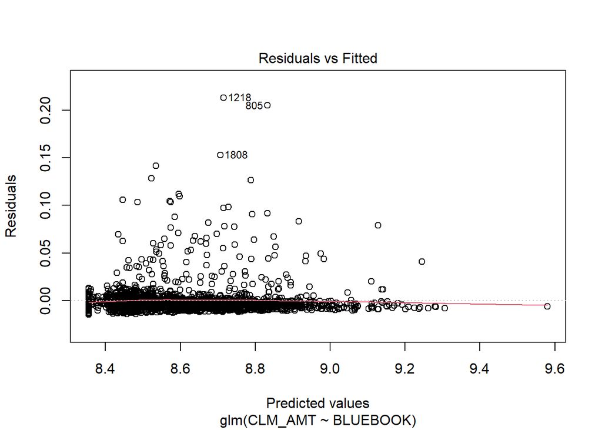

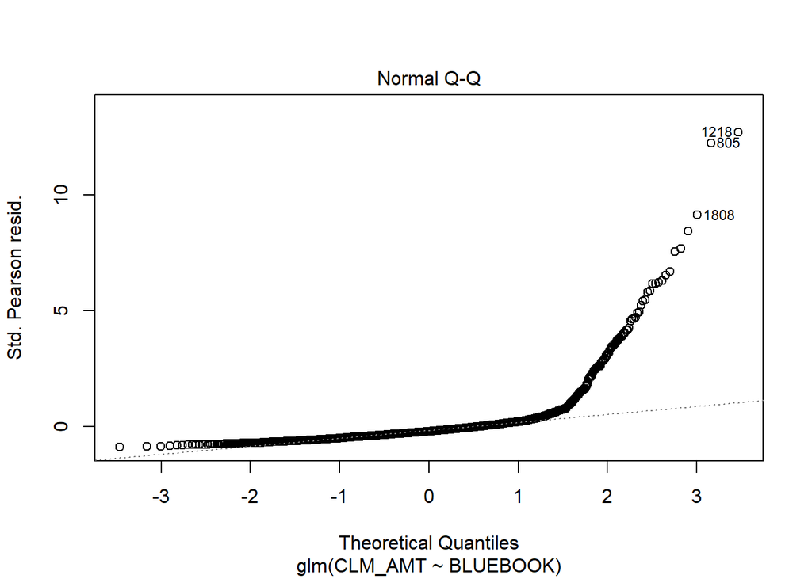

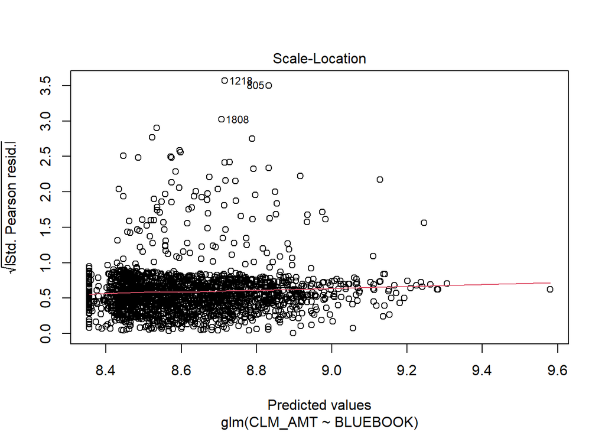

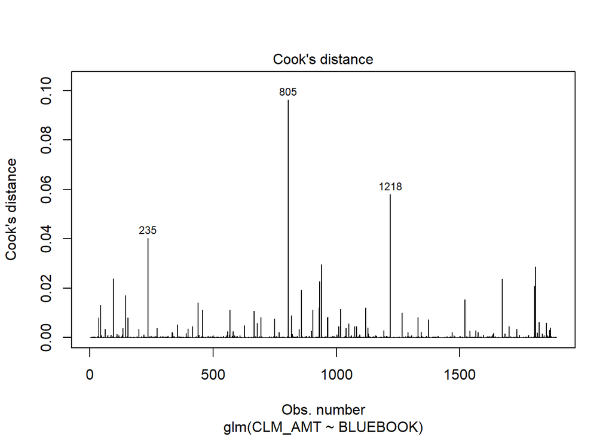

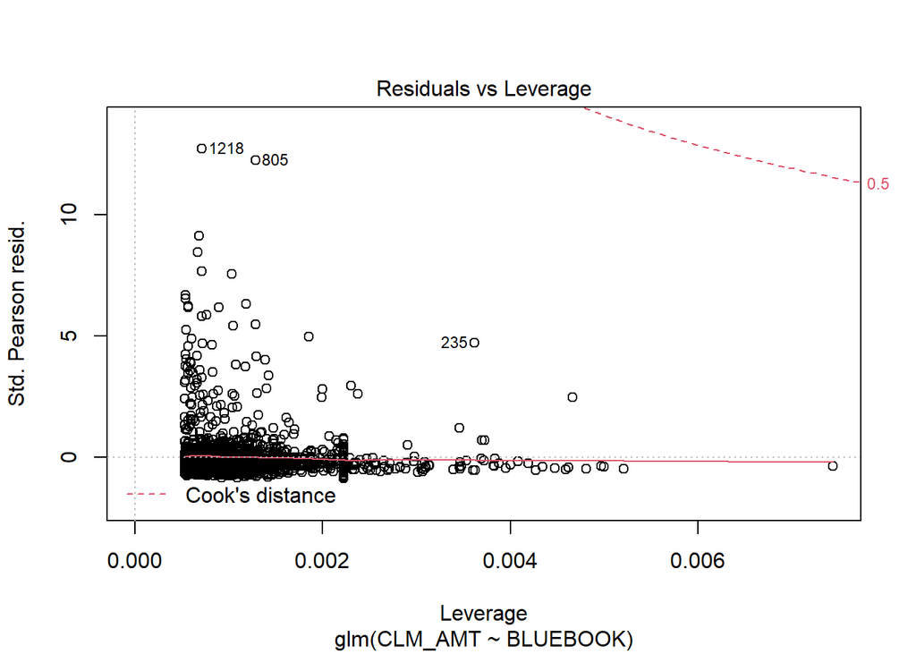

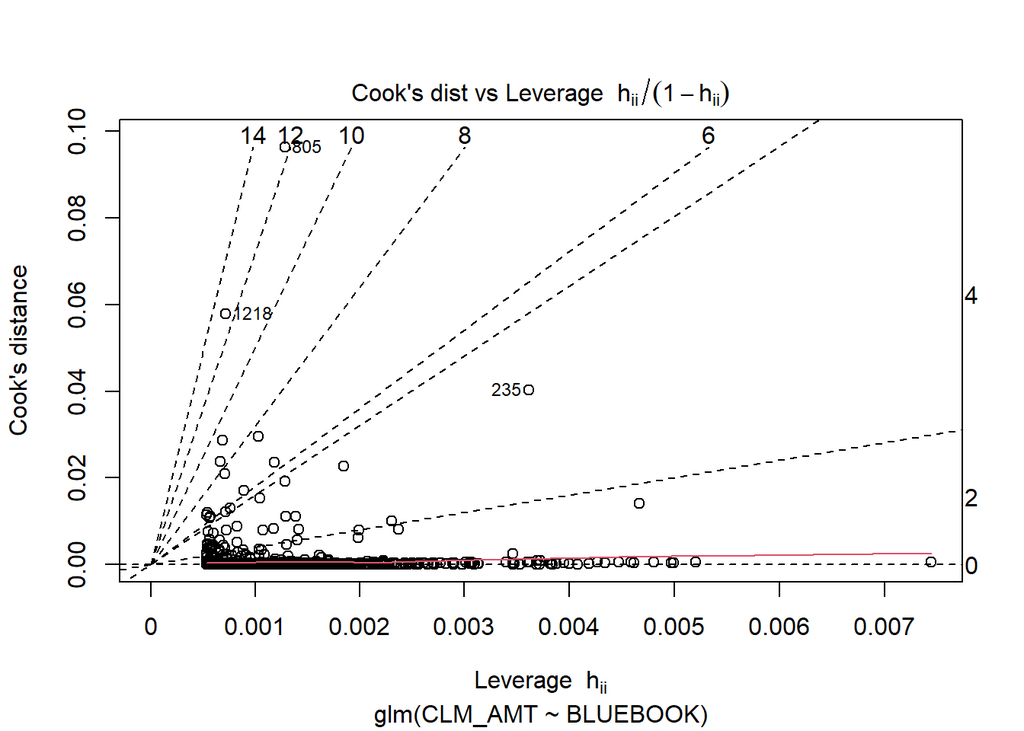

```r
plot(model_1, 1:6)
```

Powyżej przedstawiono wykresy diagnostyczne dla modelu 1 ze zmienną BLUEBOOK jako jedynym predyktorem. Stwierdzono występowanie wartości wyraźnie odstających od pozostałych (1218, 805) i podjęto decyzję o ich usunięciu, ponieważ pojedyncze duże szkody mogą utrudniać wykrycie związków pomiędzy zmiennymi.

Aby zachować porównywalność kryterium AIC po usunięciu ww. obserwacji, poniżej ponownie oszacowano model z jedną zmienną objaśniającą BLUEBOOK, z którym będą poróWnywane kolejne modele.

```r
model_1_out <- glm(CLM_AMT ~ BLUEBOOK, data=c(Y,X), family=inverse.gaussian(link="log"), subset=-c(1218, 805))
summary(model_1_out)
```

```
##
## Call:
## glm(formula = CLM_AMT ~ BLUEBOOK, family = inverse.gaussian(link = "log"),
##     data = c(Y, X), subset = -c(1218, 805))
##
## Deviance Residuals:
##       Min         1Q     Median         3Q        Max
## -0.181436  -0.009865  -0.003901   0.001032   0.043915
##
## Coefficients:
##              Estimate Std. Error t value Pr(>|t|)
## (Intercept) 8.339e+00  5.295e-02 157.486  < 2e-16 ***
## BLUEBOOK    1.918e-05  3.530e-06   5.435 6.19e-08 ***
## ---
## Signif. codes:  0 '***' 0.001 '**' 0.01 '*' 0.05 '.' 0.1 ' ' 1
##
## (Dispersion parameter for inverse.gaussian family taken to be 0.0002506761)
##
##     Null deviance: 0.35238  on 1890  degrees of freedom
## Residual deviance: 0.34518  on 1889  degrees of freedom
## AIC: 36038
##
## Number of Fisher Scoring iterations: 9
```

### Modele z interakcjami

W kolejnym kroku zbudowano modele ze zmienną BLUEBOOK w interakcji z poszczególnymi pozostałymi zmiennymi.

```r
for (c in names(X)) {
  print(c)
  if (c != 'BLUEBOOK') {
    tryCatch({
      model_x <- glm(CLM_AMT ~ BLUEBOOK * get(c), data=c(Y,X), family=inverse.gaussian(link="log"), subset=-c(1218, 805))
      print(summary(model_x)$coefficients)
      cat('AIC: ', model_x$aic)
      cat('\n\n')
    }, error=function(cond) {cat('Error occured for ', c, '\n')})
  }
}
```

```
## [1] "KIDSDRIV"
##                      Estimate   Std. Error     t value     Pr(>|t|)
## (Intercept)      8.312429e+00 5.687780e-02 146.1454041 0.000000e+00
## BLUEBOOK         2.007760e-05 3.827036e-06   5.2462527 1.726735e-07
## get(c)           9.387925e-02 8.765783e-02   1.0709739 2.843181e-01
## BLUEBOOK:get(c) -2.936628e-06 5.747115e-06  -0.5109742 6.094289e-01
## AIC:  36038.88
##
## [1] "AGE"
##                      Estimate   Std. Error     t value      Pr(>|t|)
## (Intercept)      8.372561e+00 2.470254e-01 33.89351933 4.412282e-197
## BLUEBOOK         2.012970e-05 1.722082e-05  1.16891670  2.425848e-01
## get(c)          -8.444855e-04 5.650381e-03 -0.14945638  8.812095e-01
## BLUEBOOK:get(c) -1.605662e-08 3.813826e-07 -0.04210108  9.664226e-01
## AIC:  36041.42
##
## [1] "HOMEKIDS"
##                      Estimate   Std. Error     t value     Pr(>|t|)
## (Intercept)      8.359405e+00 6.792905e-02 123.0608324 0.0000000000
## BLUEBOOK         1.523116e-05 4.344682e-06   3.5057014 0.0004660443
## get(c)          -1.956410e-02 4.341364e-02  -0.4506441 0.6522978471
## BLUEBOOK:get(c)  4.191065e-06 3.099349e-06   1.3522404 0.1764604560
## AIC:  36036.54
##
## [1] "YOJ"
##                      Estimate   Std. Error   t value   Pr(>|t|)
## (Intercept)      8.168155e+00 1.094871e-01 74.603826 0.00000000
## BLUEBOOK         2.945988e-05 9.116074e-06  3.231642 0.00125202
## get(c)           1.776408e-02 1.035897e-02  1.714849 0.08653708
## BLUEBOOK:get(c) -1.037143e-06 8.125871e-07 -1.276347 0.20199001
## AIC:  36037.94
##
## [1] "INCOME"
## Error occured for  INCOME
## [1] "PARENT1"
##                          Estimate   Std. Error    t value    Pr(>|t|)
## (Intercept)          8.385863e+00 6.038830e-02 138.865709 0.000000000
## BLUEBOOK             1.411832e-05 3.888467e-06   3.630819 0.000290057
## get(c)TRUE          -1.651573e-01 1.296590e-01  -1.273782 0.202897535
## BLUEBOOK:get(c)TRUE  1.968443e-05 9.373026e-06   2.100115 0.035851158
```

[output cut: 128 more lines]

```
## [1] "YOJ_2"
##                               Estimate   Std. Error    t value   Pr(>|t|)
## (Intercept)               8.198368e+00 1.128148e-01 72.6710447 0.00000000
## BLUEBOOK                  2.334465e-05 9.589681e-06  2.4343513 0.01501069
## get(c)7 or more           1.841424e-01 1.277623e-01  1.4412885 0.14966912
## BLUEBOOK:get(c)7 or more -6.013152e-06 1.032708e-05 -0.5822705 0.56045403
## AIC:  36037.5
##
## [1] "CAR_TYPE_2"
##                               Estimate   Std. Error     t value     Pr(>|t|)
## (Intercept)               8.330710e+00 5.932634e-02 140.4217611 0.000000e+00
## BLUEBOOK                  1.985493e-05 4.651832e-06   4.2681965 2.068321e-05
## get(c)Truck/Van           1.629693e-01 2.848982e-01   0.5720264 5.673722e-01
## BLUEBOOK:get(c)Truck/Van -6.994404e-06 1.221056e-05  -0.5728161 5.668375e-01
## AIC:  36041.25
```

Modelem o największym potencjale predykcyjnym spośród oszacowanych powyżej okazał się model zawierający zmienne BLUEBOOK i MSTATUS oraz interakcję pomiędzy nimi. Dla większej czytelności poniżej oszacowano wyłącznie ww. model i oznaczono go jako model nr 2.

```r
model_2_out <- glm(CLM_AMT ~ BLUEBOOK*MSTATUS, data=c(Y,X), family=inverse.gaussian(link="log"), subset=-c(1218, 805))
summary(model_2_out)
```

```
##
## Call:
## glm(formula = CLM_AMT ~ BLUEBOOK * MSTATUS, family = inverse.gaussian(link = "log"),
##     data = c(Y, X), subset = -c(1218, 805))
##
## Deviance Residuals:
##       Min         1Q     Median         3Q        Max
## -0.181475  -0.009736  -0.003738   0.001037   0.048900
##
## Coefficients:
##                        Estimate Std. Error t value Pr(>|t|)
## (Intercept)           8.226e+00  7.670e-02 107.249  < 2e-16 ***
## BLUEBOOK              3.000e-05  5.281e-06   5.682 1.54e-08 ***
## MSTATUSTRUE           2.423e-01  1.052e-01   2.303 0.021415 *
## BLUEBOOK:MSTATUSTRUE -2.377e-05  6.990e-06  -3.401 0.000685 ***
## ---
## Signif. codes:  0 '***' 0.001 '**' 0.01 '*' 0.05 '.' 0.1 ' ' 1
##
## (Dispersion parameter for inverse.gaussian family taken to be 0.0002493522)
##
##     Null deviance: 0.35238  on 1890  degrees of freedom
## Residual deviance: 0.34235  on 1887  degrees of freedom
## AIC: 36026
##
## Number of Fisher Scoring iterations: 10
```

Wszystkie parametry w powyższym modelu są statystycznie istotne, a wartość kryterium AIC spadła z 36038 do 36026.

Poniżej oszacowano wiele modeli zawierających zmienną BLUEBOOK oraz dwie inne zmienne we wzajemnej interakcji.

```r
inter_results <- data.frame(matrix(nrow=1, ncol=3))
names(inter_results) <- c('AIC', 'Col 1', 'Col 2')
inter_cols <- names(X)
inter_cols <- inter_cols[! inter_cols %in% c('OG_DATA', 'BLUEBOOK')]

for (c in inter_cols) {
  for (d in inter_cols) {
    if (c != d) {
      tryCatch({
        model_x <- glm(CLM_AMT ~ BLUEBOOK + get(c)*get(d), data=c(Y,X), family=inverse.gaussian(link="log"), subset=-c(1218, 805))
        inter_results <- rbind(inter_results, c(model_x$aic, c, d))
        #cat(model_x$aic, ' ', c, ':', d, '\n')
      }, error=function(cond) {cat('Error occured for ', c, ' and ', d, '\n')})
    }
  }
  inter_cols <- inter_cols[! inter_cols %in% c(c)]
}
inter_results <- na.omit(inter_results)
inter_results$AIC <- as.numeric(inter_results$AIC)
```

```r
head(inter_results[order(inter_results$AIC),])
```

```
##          AIC    Col 1      Col 2
## 55  36029.94 HOMEKIDS   CLM_FREQ
## 195 36031.97  CAR_USE        TIF
## 145 36032.22  MSTATUS CAR_TYPE_2
## 50  36034.01 HOMEKIDS   TRAVTIME
## 19  36034.01 KIDSDRIV    REVOKED
## 247 36034.10  REVOKED      YOJ_2
```

Żaden z uzyskanych modeli nie pozwolił na obniżenie wartości kryterium AIC. Tym samym modele te nie będą dalej analizowane.

W kolejnym kroku oszacowano modele ze zmiennymi BLUEBOOK i MSTATUS we wzajemnej interakcji oraz z dodatkowymi dwiema zmiennymi również w interakcji.

```r
inter_results <- data.frame(matrix(nrow=1, ncol=3))
names(inter_results) <- c('AIC', 'Col 1', 'Col 2')
inter_cols <- names(X)
inter_cols <- inter_cols[! inter_cols %in% c('OG_DATA', 'BLUEBOOK', 'MSTATUS')]

for (c in inter_cols) {
  for (d in inter_cols) {
    if (c != d) {
      tryCatch({
        model_x <- glm(CLM_AMT ~ BLUEBOOK*MSTATUS + get(c)*get(d), data=c(Y,X), family=inverse.gaussian(link="log"), subset=-c(1218, 805))
        inter_results <- rbind(inter_results, c(model_x$aic, c, d))
        #cat(model_x$aic, ' ', c, ':', d, '\n')
      }, error=function(cond) {cat('Error occured for ', c, ' and ', d, '\n')})
    }
  }
  inter_cols <- inter_cols[! inter_cols %in% c(c)]
}
inter_results <- na.omit(inter_results)
inter_results$AIC <- as.numeric(inter_results$AIC)
```

```r
head(inter_results[order(inter_results$AIC),])
```

```
##          AIC    Col 1    Col 2
## 50  36019.55 HOMEKIDS CLM_FREQ
## 153 36019.88  CAR_USE      TIF
## 5   36020.22 KIDSDRIV   INCOME
## 7   36020.69 KIDSDRIV HOME_VAL
## 18  36021.01 KIDSDRIV  REVOKED
## 45  36021.13 HOMEKIDS TRAVTIME
```

Tym razem uzyskano modele o niższej wartości kryterium AIC i zostaną one poddane dalszej analizie. Poniżej przedstawiono wyniki oszacowania dwóch najlepszych modeli zawierających oprócz zmiennych BLUEBOOK i MSTATUS również zmienne HOMEKIDS i CLM_FREQ w interakcji (model 3) oraz zmienne CAR_USE i TIF w interakcji (model 4).

```r
model_3_out <- glm(CLM_AMT ~ BLUEBOOK*MSTATUS + HOMEKIDS*CLM_FREQ, data=c(Y,X), family=inverse.gaussian(link="log"), subset=-c(1218, 805))
summary(model_3_out)
```

```
##
## Call:
## glm(formula = CLM_AMT ~ BLUEBOOK * MSTATUS + HOMEKIDS * CLM_FREQ,
##     family = inverse.gaussian(link = "log"), data = c(Y, X),
##     subset = -c(1218, 805))
##
## Deviance Residuals:
##       Min         1Q     Median         3Q        Max
## -0.181285  -0.009768  -0.003727   0.001146   0.045299
##
## Coefficients:
##                        Estimate Std. Error t value Pr(>|t|)
## (Intercept)           8.276e+00  8.625e-02  95.958  < 2e-16 ***
## BLUEBOOK              2.876e-05  5.149e-06   5.586 2.66e-08 ***
## MSTATUSTRUE           2.114e-01  1.028e-01   2.056  0.03993 *
## HOMEKIDS             -1.884e-02  3.018e-02  -0.624  0.53249
## CLM_FREQ             -6.096e-02  2.623e-02  -2.324  0.02023 *
## BLUEBOOK:MSTATUSTRUE -2.202e-05  6.806e-06  -3.235  0.00124 **
## HOMEKIDS:CLM_FREQ     5.062e-02  1.845e-02   2.743  0.00615 **
## ---
## Signif. codes:  0 '***' 0.001 '**' 0.01 '*' 0.05 '.' 0.1 ' ' 1
##
## (Dispersion parameter for inverse.gaussian family taken to be 0.0002384245)
##
##     Null deviance: 0.35238  on 1890  degrees of freedom
## Residual deviance: 0.34009  on 1884  degrees of freedom
## AIC: 36020
##
## Number of Fisher Scoring iterations: 11
```

```r
model_4_out <- glm(CLM_AMT ~ BLUEBOOK*MSTATUS + CAR_USE*TIF, data=c(Y,X), family=inverse.gaussian(link="log"), subset=-c(1218, 805))
summary(model_4_out)
```

```
##
## Call:
## glm(formula = CLM_AMT ~ BLUEBOOK * MSTATUS + CAR_USE * TIF, family = inverse.gaussian(link = "log"),
##     data = c(Y, X), subset = -c(1218, 805))
##
## Deviance Residuals:
##       Min         1Q     Median         3Q        Max
## -0.181504  -0.009631  -0.003717   0.001057   0.041065
##
## Coefficients:
##                         Estimate Std. Error t value Pr(>|t|)
## (Intercept)            8.302e+00  8.764e-02  94.730  < 2e-16 ***
## BLUEBOOK               2.848e-05  5.201e-06   5.475 4.95e-08 ***
## MSTATUSTRUE            2.429e-01  1.026e-01   2.368 0.017965 *
## CAR_USECommercial     -1.065e-01  8.530e-02  -1.249 0.211842
## TIF                   -1.988e-02  9.009e-03  -2.207 0.027468 *
## BLUEBOOK:MSTATUSTRUE  -2.382e-05  6.780e-06  -3.513 0.000454 ***
## CAR_USECommercial:TIF  3.676e-02  1.329e-02   2.767 0.005711 **
## ---
## Signif. codes:  0 '***' 0.001 '**' 0.01 '*' 0.05 '.' 0.1 ' ' 1
##
## (Dispersion parameter for inverse.gaussian family taken to be 0.0002371478)
##
##     Null deviance: 0.35238  on 1890  degrees of freedom
## Residual deviance: 0.34015  on 1884  degrees of freedom
## AIC: 36020
##
## Number of Fisher Scoring iterations: 10
```

Poniżej porównano 4 najlepsze modele wykorzystując w tym celu odchylenie standardowe reszt, kryterium AIC oraz miary pseudo-R^2.

```r
ocena_modelu_GLM <- function(model) {
  odch_std_reszt <- (model$deviance/model$df.residual)^0.5
  kryterium_AIC <- c(model$aic)
  McFadden<-pR2(model)[4]
  Cragg_Uhler<-pR2(model)[6]
  ocena <- data.frame(odch_std_reszt, kryterium_AIC, McFadden, Cragg_Uhler)
  return(ocena)
}

ocena_modeli <- rbind(model_1=ocena_modelu_GLM(model_1_out),
                      model_2=ocena_modelu_GLM(model_2_out),
                      model_3=ocena_modelu_GLM(model_3_out),
                      model_4=ocena_modelu_GLM(model_4_out))
```

```
## fitting null model for pseudo-r2
## fitting null model for pseudo-r2
## fitting null model for pseudo-r2
## fitting null model for pseudo-r2
## fitting null model for pseudo-r2
## fitting null model for pseudo-r2
## fitting null model for pseudo-r2
## fitting null model for pseudo-r2
```

```r
ocena_modeli
```

```
##         odch_std_reszt kryterium_AIC     McFadden  Cragg_Uhler
## model_1     0.01351790      36037.64 2.719312e-05 0.0005180251
## model_2     0.01346943      36026.05 4.598187e-04 0.0087234801
## model_3     0.01343568      36019.55 8.066593e-04 0.0152532020
## model_4     0.01343684      36019.88 7.975556e-04 0.0150823639
```

Jakość modeli zweryfikowano wykorzystując w tym celu zbiór testowy i porównując średnią wartość prognozowanych wartości ze średnią wartością rzeczywistych wartości. W celu dodatkowej weryfikacji do poniższych wynikóW dołączono również model 1 przed wykluczeniem wartości odstających.

```r
X_test <- subset(data_test[data_test$CLAIM_FLAG == TRUE,], select=-c(ID, CLM_AMT, CLAIM_FLAG))
Y_test <- data_test[data_test$CLAIM_FLAG == TRUE,]['CLM_AMT']
X_Y_test <- c(X_test, Y_test)

prediction_test <- data.frame(cbind(
  real=X_Y_test$CLM_AMT,
  model_1_with_out=exp(predict(model_1, X_Y_test)),
  model_1=exp(predict(model_1_out, X_Y_test)),
  model_2=exp(predict(model_2_out, X_Y_test)),
  model_3=exp(predict(model_3_out, X_Y_test)),
  model_4=exp(predict(model_4_out, X_Y_test))
))

rbind(
  real=mean(prediction_test$real),
  model_1_with_out=mean(prediction_test$model_1_with_out),
  model_1=mean(prediction_test$model_1),
  model_2=mean(prediction_test$model_2),
  model_3=mean(prediction_test$model_3),
  model_4=mean(prediction_test$model_4)
)
```

```
##                      [,1]
## real             5716.048
## model_1_with_out 5734.693
## model_1          5600.588
## model_2          5651.306
## model_3          5627.121
## model_4          5630.139
```

Dla danych ze zbioru testowego średnia wartość szkody wyniosła $5716. Średnia prognoza każdego z modeli z wykluczonymi wartościami odstającymi była niższa od rzeczywistej wartości. Prognozy najbliżej rzeczywistej średniej wartości uzyskano z modelu 1 przed wykluczeniem wartości odstających oraz modelu 2.